# Titanic: Machine Learning from Disaster

- Objective - Create a model that predicts which passengers survived from the Titanic shipwreck
- Dataset Source - https://www.kaggle.com/c/titanic/data
- Dataset Format - .csv

## Some useful information

The sinking of the Titanic is one of the most infamous shipwrecks in history.

On April 15, 1912, during her maiden voyage, the widely considered “unsinkable” RMS Titanic sank after colliding with an iceberg. Unfortunately, there weren’t enough lifeboats for everyone onboard, resulting in the death of 1502 out of 2224 passengers and crew.

While there was some element of luck involved in surviving, it seems some groups of people were more likely to survive than others.

### Data Description

| **Variable** | **Definition** | **Key** |
| --- | --- | --- |
| survival | Survival | 0 = No, 1 = Yes |
| pclass | Ticket class | 1 = 1st, 2 = 2nd, 3 = 3rd |
| sex | Sex |  |
| Age | Age in years |  |
| sibsp | # of siblings / spouses aboard the Titanic |  |
| parch | # of parents / children aboard the Titanic |  |
| ticket | Ticket number |  |
| fare | Passenger fare |  |
| cabin | Cabin number |  |
| embarked | Port of Embarkation | C = Cherbourg, Q = Queenstown, S = Southampton |

### Import Library

```python
from IPython.display import display
from IPython.display import HTML

import numpy as np
import pandas as pd
import seaborn as sns
import matplotlib.pyplot as plt
import graphviz
from sklearn.tree import export_graphviz
from xgboost import XGBClassifier
from xgboost import plot_tree
from sklearn.decomposition import PCA
from sklearn.model_selection import RandomizedSearchCV
from sklearn.model_selection import train_test_split, StratifiedKFold
from sklearn.feature_selection import SelectFromModel
from sklearn.preprocessing import StandardScaler, MinMaxScaler
from sklearn.metrics import confusion_matrix, f1_score, accuracy_score, roc_auc_score
from sklearn.neural_network import MLPClassifier
from sklearn.neighbors import KNeighborsClassifier
from sklearn.naive_bayes import GaussianNB
from sklearn.linear_model import LogisticRegression
from sklearn.tree import DecisionTreeClassifier
from sklearn.ensemble import AdaBoostClassifier, RandomForestClassifier, GradientBoostingClassifier
from sklearn.ensemble import BaggingClassifier, ExtraTreesClassifier
```

### Load Train and Test Data

```python
raw_train_data = pd.read_csv("train.csv")
raw_test_data = pd.read_csv("test.csv")

print("Train data shape : ", raw_train_data.shape)
display(raw_train_data.sample(3))
print("="*120)

print("Test data shape : ", raw_test_data.shape)
display(raw_test_data.sample(3))
```

```
Train data shape :  (891, 12)
```

|  | PassengerId | Survived | Pclass | Name | Sex | Age | SibSp | Parch | Ticket | Fare | Cabin | Embarked |
| --- | --- | --- | --- | --- | --- | --- | --- | --- | --- | --- | --- | --- |
| 214 | 215 | 0 | 3 | Kiernan, Mr. Philip | male | NaN | 1 | 0 | 367229 | 7.75 | NaN | Q |
| 481 | 482 | 0 | 2 | Frost, Mr. Anthony Wood "Archie" | male | NaN | 0 | 0 | 239854 | 0.00 | NaN | S |
| 497 | 498 | 0 | 3 | Shellard, Mr. Frederick William | male | NaN | 0 | 0 | C.A. 6212 | 15.10 | NaN | S |

```
========================================================================================================================
Test data shape :  (418, 11)
```

|  | PassengerId | Pclass | Name | Sex | Age | SibSp | Parch | Ticket | Fare | Cabin | Embarked |
| --- | --- | --- | --- | --- | --- | --- | --- | --- | --- | --- | --- |
| 200 | 1092 | 3 | Murphy, Miss. Nora | female | NaN | 0 | 0 | 36568 | 15.50 | NaN | Q |
| 342 | 1234 | 3 | Sage, Mr. John George | male | NaN | 1 | 9 | CA. 2343 | 69.55 | NaN | S |
| 266 | 1158 | 1 | Chisholm, Mr. Roderick Robert Crispin | male | NaN | 0 | 0 | 112051 | 0.00 | NaN | S |

```python
raw_train_data.info()
```

```
<class 'pandas.core.frame.DataFrame'>
RangeIndex: 891 entries, 0 to 890
Data columns (total 12 columns):
 #   Column       Non-Null Count  Dtype
---  ------       --------------  -----
 0   PassengerId  891 non-null    int64
 1   Survived     891 non-null    int64
 2   Pclass       891 non-null    int64
 3   Name         891 non-null    object
 4   Sex          891 non-null    object
 5   Age          714 non-null    float64
 6   SibSp        891 non-null    int64
 7   Parch        891 non-null    int64
 8   Ticket       891 non-null    object
 9   Fare         891 non-null    float64
 10  Cabin        204 non-null    object
 11  Embarked     889 non-null    object
dtypes: float64(2), int64(5), object(5)
memory usage: 83.7+ KB
```

```python
raw_train_data[raw_train_data['Fare']>263]
```

|  | PassengerId | Survived | Pclass | Name | Sex | Age | SibSp | Parch | Ticket | Fare | Cabin | Embarked |
| --- | --- | --- | --- | --- | --- | --- | --- | --- | --- | --- | --- | --- |
| 258 | 259 | 1 | 1 | Ward, Miss. Anna | female | 35.0 | 0 | 0 | PC 17755 | 512.3292 | NaN | C |
| 679 | 680 | 1 | 1 | Cardeza, Mr. Thomas Drake Martinez | male | 36.0 | 0 | 1 | PC 17755 | 512.3292 | B51 B53 B55 | C |
| 737 | 738 | 1 | 1 | Lesurer, Mr. Gustave J | male | 35.0 | 0 | 0 | PC 17755 | 512.3292 | B101 | C |

### Which gender is more likely to survive?

Female has higher chance to survive rather than male

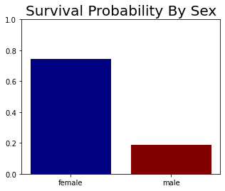

```python
survived_by_sex = raw_train_data.groupby("Sex")['Survived'].mean().to_frame()

plt.figure(figsize=(5,4))
plt.bar(x=survived_by_sex.index, height=survived_by_sex['Survived'], color=('navy','maroon'))
plt.title("Survival Probability By Sex", fontsize=20)
plt.ylim(0,1)
plt.show()
```

### How likely is the passenger survived in each Pclass?

Higher class (1,2,3 respectively) have higher probability to survived.

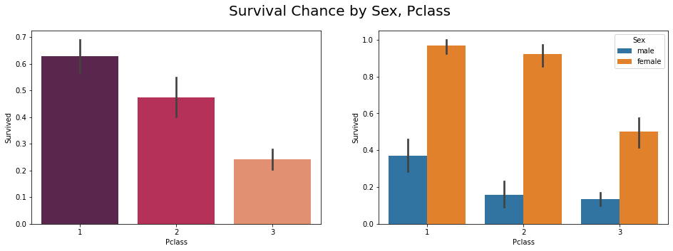

```python
fig,ax = plt.subplots(1, 2, figsize=(16,5))
ax = ax.ravel()

sns.barplot(x='Pclass', y='Survived', data=raw_train_data, ax=ax[0], palette='rocket')
sns.barplot(x='Pclass', y='Survived', hue='Sex', data=raw_train_data, ax=ax[1])
plt.suptitle("Survival Chance by Sex, Pclass", fontsize=20)
plt.show()
```

### How likely is people survived from different Embarked?

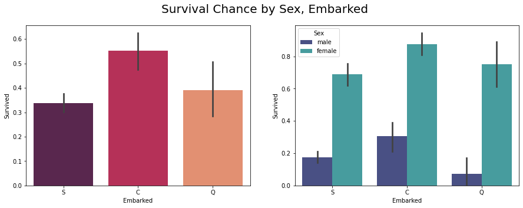

```python
fig = plt.figure(figsize=(15,5))
ax1 = fig.add_subplot(121)
ax2 = fig.add_subplot(122)

sns.barplot(x='Embarked', y='Survived', data=raw_train_data, ax=ax1, palette='rocket')
sns.barplot(x='Embarked', y='Survived', hue='Sex', data=raw_train_data, ax=ax2, palette='mako')
plt.suptitle("Survival Chance by Sex, Embarked", fontsize=20)
plt.show()
```

### How much chance of survival in every Pclass vs different Embarked?

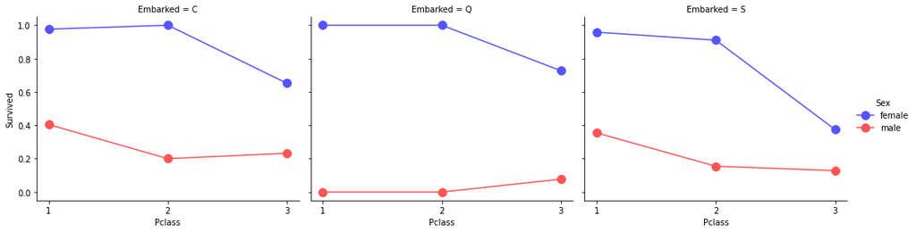

```python
embarked_class_sex = raw_train_data.groupby(['Embarked','Pclass','Sex'])['Survived'].mean().reset_index()
fg = sns.FacetGrid(embarked_class_sex, col='Embarked', hue='Sex', aspect=1.2, height=4, palette='seismic')
fg.map(plt.plot, 'Pclass', 'Survived', marker='o', markersize=10)
fg.add_legend()
fg.set(xticks=[1,2,3])
plt.show()
```

### Age distribution for survived and unsurvived passenger

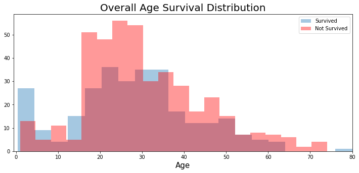

```python
plt.figure(figsize=(12,5))
sns.distplot(a=raw_train_data.loc[raw_train_data.Survived==1,'Age'], bins=20, kde=False, label='Survived')
sns.distplot(a=raw_train_data.loc[raw_train_data.Survived==0,'Age'], bins=20, kde=False, color='red', label='Not Survived')
plt.xlim(raw_train_data.Age.min()-1, raw_train_data.Age.max())
plt.title("Overall Age Survival Distribution", fontsize=20)
plt.xlabel("Age", fontsize=15)
plt.legend()
plt.show()
```

### Age Distribution for every sex vs survived

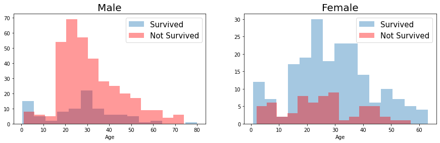

```python
fig, ax = plt.subplots(1,2, figsize=(15,4))
ax = ax.ravel()

male = (raw_train_data.Sex == 'male')
female = (raw_train_data.Sex == 'female')

survived = (raw_train_data.Survived==1)
not_survived = (raw_train_data.Survived==0)

sns.distplot(a = raw_train_data.loc[male & survived, 'Age'].dropna(), \
             ax = ax[0], kde=False, bins=15, label='Survived')
sns.distplot(a = raw_train_data.loc[male & not_survived, 'Age'].dropna(), \
             ax = ax[0], color='red', kde=False, bins=15, label='Not Survived')

sns.distplot(a = raw_train_data.loc[female & survived, 'Age'].dropna(), \
             ax = ax[1], kde=False, bins=15, label='Survived')
sns.distplot(a = raw_train_data.loc[female & not_survived, 'Age'].dropna(), \
             ax = ax[1], color='red', kde=False, bins=15, label='Not Survived')

ax[0].legend(fontsize=15)
ax[1].legend(fontsize=15)

ax[0].set_title("Male", fontsize=20)
ax[1].set_title("Female", fontsize=20)
plt.show()
```

### Does higher fare give higher survival probability?

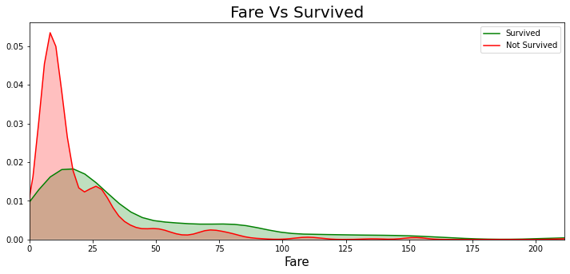

```python
plt.figure(figsize=(12,5))
sns.kdeplot(data=raw_train_data.loc[raw_train_data.Survived==1,'Fare'], shade=True, label='Survived', color='green')
sns.kdeplot(data=raw_train_data.loc[raw_train_data.Survived==0,'Fare'], shade=True, label='Not Survived', color='red')
plt.xlim(raw_train_data.Fare.quantile(0.01),
         raw_train_data.Fare.quantile(0.98))
plt.xlabel("Fare", fontsize=15)
plt.title("Fare Vs Survived", fontsize=20)
plt.show()
```

### Does the number of families affected the chances of survival?

```python
parch = raw_train_data.groupby(['Parch'])['Survived'].mean()
sibsp = raw_train_data.groupby(['SibSp'])['Survived'].mean()

family = pd.concat([parch.to_frame().rename(columns={'Survived':'Survived(Parch)'}),
                    sibsp.to_frame().rename(columns={'Survived':'Survived(SibSp)'})], axis=1)
family.index.name = "Number of Parch/SibSp"
family
```

| Number of Parch/SibSp | Survived(Parch) | Survived(SibSp) |
| --- | --- | --- |
| 0 | 0.343658 | 0.345395 |
| 1 | 0.550847 | 0.535885 |
| 2 | 0.500000 | 0.464286 |
| 3 | 0.600000 | 0.250000 |
| 4 | 0.000000 | 0.166667 |
| 5 | 0.200000 | 0.000000 |
| 6 | 0.000000 | NaN |
| 8 | NaN | 0.000000 |

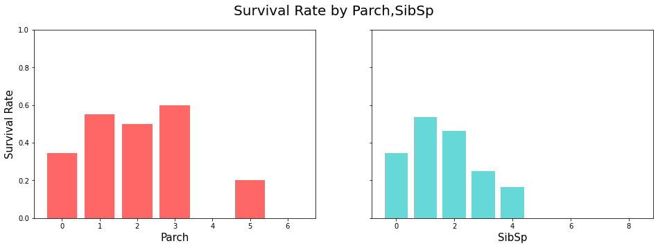

```python
fig,ax = plt.subplots(1,2,figsize=(16,5), sharey=True)
ax = ax.ravel()
ax[0].set_ylim(0,1)

ax[0].bar(x = parch.index, height = parch.values, color='r', alpha=.6)
ax[1].bar(x = sibsp.index, height = sibsp.values, color='c', alpha=.6)

ax[0].set_xlabel("Parch", fontsize=15)
ax[1].set_xlabel("SibSp", fontsize=15)
ax[0].set_ylabel("Survival Rate", fontsize=15)

plt.suptitle("Survival Rate by Parch,SibSp", fontsize=20)
plt.show()
```

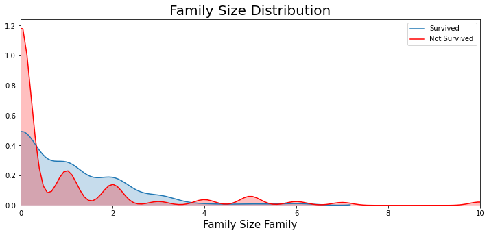

```python
plt.figure(figsize=(12,5))
raw_train_data['FamilySize'] = raw_train_data.Parch + raw_train_data.SibSp

sns.kdeplot(data=raw_train_data.loc[raw_train_data.Survived==1,'FamilySize'], shade=True, label='Survived')
sns.kdeplot(data=raw_train_data.loc[raw_train_data.Survived==0,'FamilySize'], shade=True, label='Not Survived', color='red')
plt.xlim(raw_train_data.FamilySize.min(), \
         raw_train_data.FamilySize.max())

raw_train_data.drop(columns=['FamilySize'], inplace=True)
plt.title("Family Size Distribution", fontsize=20)
plt.xlabel("Family Size Family", fontsize=15)
plt.show()
```

### Age distribution for every Pclass and Survived group

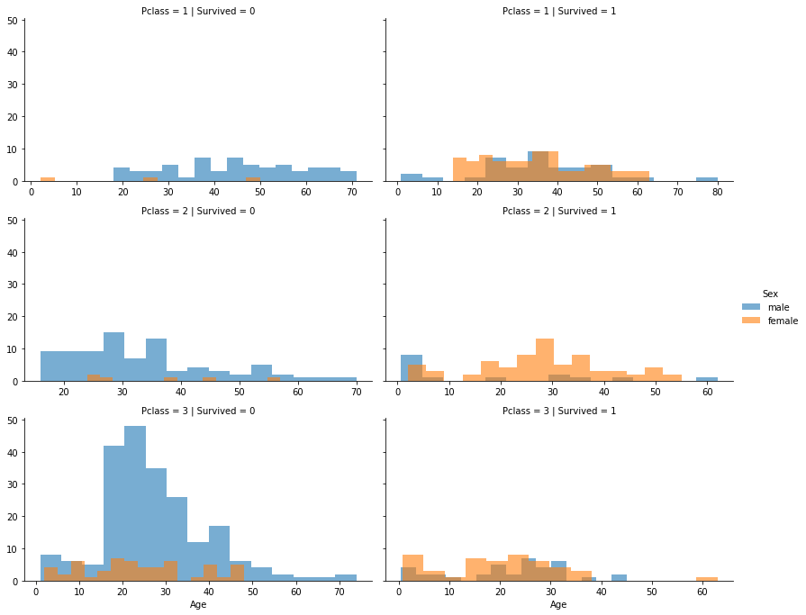

```python
fg1 = sns.FacetGrid(raw_train_data, col='Survived', row='Pclass', hue='Sex',
                    height=3.2, aspect=1.8, sharex=False)
fg1.map(plt.hist, 'Age', bins=15, alpha=.6)
fg1.add_legend()
plt.show()
```

### Combine train and test data for getting more insight

Combined overall data is also used for preprocessing and generating new feature

```python
all_data = pd.concat([raw_train_data[raw_test_data.columns], raw_test_data], axis=0).set_index("PassengerId")
all_data
```

| PassengerId | Pclass | Name | Sex | Age | SibSp | Parch | Ticket | Fare | Cabin | Embarked |
| --- | --- | --- | --- | --- | --- | --- | --- | --- | --- | --- |
| 1 | 3 | Braund, Mr. Owen Harris | male | 22.0 | 1 | 0 | A/5 21171 | 7.2500 | NaN | S |
| 2 | 1 | Cumings, Mrs. John Bradley (Florence Briggs Th... | female | 38.0 | 1 | 0 | PC 17599 | 71.2833 | C85 | C |
| 3 | 3 | Heikkinen, Miss. Laina | female | 26.0 | 0 | 0 | STON/O2. 3101282 | 7.9250 | NaN | S |
| 4 | 1 | Futrelle, Mrs. Jacques Heath (Lily May Peel) | female | 35.0 | 1 | 0 | 113803 | 53.1000 | C123 | S |
| 5 | 3 | Allen, Mr. William Henry | male | 35.0 | 0 | 0 | 373450 | 8.0500 | NaN | S |
| ... | ... | ... | ... | ... | ... | ... | ... | ... | ... | ... |
| 1305 | 3 | Spector, Mr. Woolf | male | NaN | 0 | 0 | A.5. 3236 | 8.0500 | NaN | S |
| 1306 | 1 | Oliva y Ocana, Dona. Fermina | female | 39.0 | 0 | 0 | PC 17758 | 108.9000 | C105 | C |
| 1307 | 3 | Saether, Mr. Simon Sivertsen | male | 38.5 | 0 | 0 | SOTON/O.Q. 3101262 | 7.2500 | NaN | S |
| 1308 | 3 | Ware, Mr. Frederick | male | NaN | 0 | 0 | 359309 | 8.0500 | NaN | S |
| 1309 | 3 | Peter, Master. Michael J | male | NaN | 1 | 1 | 2668 | 22.3583 | NaN | C |

1309 rows × 10 columns

```python
all_data.info()
```

```
<class 'pandas.core.frame.DataFrame'>
Int64Index: 1309 entries, 1 to 1309
Data columns (total 10 columns):
 #   Column    Non-Null Count  Dtype
---  ------    --------------  -----
 0   Pclass    1309 non-null   int64
 1   Name      1309 non-null   object
 2   Sex       1309 non-null   object
 3   Age       1046 non-null   float64
 4   SibSp     1309 non-null   int64
 5   Parch     1309 non-null   int64
 6   Ticket    1309 non-null   object
 7   Fare      1308 non-null   float64
 8   Cabin     295 non-null    object
 9   Embarked  1307 non-null   object
dtypes: float64(2), int64(3), object(5)
memory usage: 112.5+ KB
```

```python
all_data.describe(include='all')
```

|  | Pclass | Name | Sex | Age | SibSp | Parch | Ticket | Fare | Cabin | Embarked |
| --- | --- | --- | --- | --- | --- | --- | --- | --- | --- | --- |
| count | 1309.000000 | 1309 | 1309 | 1046.000000 | 1309.000000 | 1309.000000 | 1309 | 1308.000000 | 295 | 1307 |
| unique | NaN | 1307 | 2 | NaN | NaN | NaN | 929 | NaN | 186 | 3 |
| top | NaN | Kelly, Mr. James | male | NaN | NaN | NaN | CA. 2343 | NaN | C23 C25 C27 | S |
| freq | NaN | 2 | 843 | NaN | NaN | NaN | 11 | NaN | 6 | 914 |
| mean | 2.294882 | NaN | NaN | 29.881138 | 0.498854 | 0.385027 | NaN | 33.295479 | NaN | NaN |
| std | 0.837836 | NaN | NaN | 14.413493 | 1.041658 | 0.865560 | NaN | 51.758668 | NaN | NaN |
| min | 1.000000 | NaN | NaN | 0.170000 | 0.000000 | 0.000000 | NaN | 0.000000 | NaN | NaN |
| 25% | 2.000000 | NaN | NaN | 21.000000 | 0.000000 | 0.000000 | NaN | 7.895800 | NaN | NaN |
| 50% | 3.000000 | NaN | NaN | 28.000000 | 0.000000 | 0.000000 | NaN | 14.454200 | NaN | NaN |
| 75% | 3.000000 | NaN | NaN | 39.000000 | 1.000000 | 0.000000 | NaN | 31.275000 | NaN | NaN |
| max | 3.000000 | NaN | NaN | 80.000000 | 8.000000 | 9.000000 | NaN | 512.329200 | NaN | NaN |

[Help Function 1] : Is there any column contains missing value?

```python
def count_missing_value(df):
    missing_col = df.isnull().sum()
    print(missing_col[missing_col>0])
```

```python
count_missing_value(all_data)
```

```
Age          263
Fare           1
Cabin       1014
Embarked       2
dtype: int64
```

[Help Function 2] : Retrieve Train Data

```python
def call_train_data(df):
    d = df.loc[raw_train_data.PassengerId].copy().reset_index(drop=True)
    return pd.concat([d, raw_train_data['Survived']], axis=1)
```

### "Name" Features

Extract name title from avaiable names

```python
all_data['Name'].head()
```

```
PassengerId
1                              Braund, Mr. Owen Harris
2    Cumings, Mrs. John Bradley (Florence Briggs Th...
3                               Heikkinen, Miss. Laina
4         Futrelle, Mrs. Jacques Heath (Lily May Peel)
5                             Allen, Mr. William Henry
Name: Name, dtype: object
```

```python
all_data['Name'].apply(lambda x: x.split(",")[1].split(".")[0]).value_counts()
```

```
 Mr              757
 Miss            260
 Mrs             197
 Master           61
 Dr                8
 Rev               8
 Col               4
 Mlle              2
 Major             2
 Ms                2
 Sir               1
 Jonkheer          1
 Capt              1
 Dona              1
 Lady              1
 the Countess      1
 Don               1
 Mme               1
Name: Name, dtype: int64
```

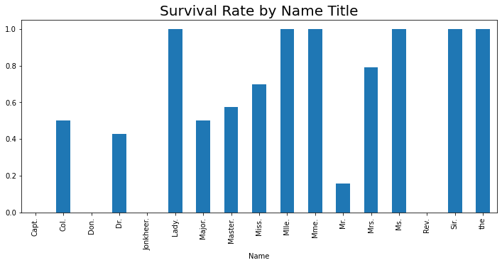

```python
df = call_train_data(all_data)
df['Name'] = df['Name'].apply(lambda x: str(x.split(',')[1].split()[0]).strip())
df.groupby(['Name'])['Survived'].mean().plot(kind='bar', figsize=(12,5))
plt.title("Survival Rate by Name Title", fontsize=20)
plt.show()
```

Some rare name title like 'Lady.', 'Mlle.', 'Mme.', 'Ms.', 'Sir.', 'the' surely survived and can be categorized as exclusive, while other name title grouped based on closest characteristics

```python
df_name_title = all_data.copy()

name_title_map = {'Mr.':'Mr', 'Miss.':'Miss/Mrs', 'Mrs.':'Miss/Mrs', 'Lady.':'Exclusive', 'Mlle.':'Exclusive',
                  'Mme.':'Exclusive', 'Ms.':'Exclusive', 'Sir.':'Exclusive', 'the':'Exclusive',
                  'Capt.':'Hopeless', 'Don.':'Hopeless', 'Johnkheer.':'Hopeless', 'Rev.':'Hopeless'}

df_name_title['Name'] = df_name_title['Name'].apply(lambda x: str(x.split(',')[1].split()[0]).strip())
df_name_title['Name'] = df_name_title['Name'].apply(lambda x: name_title_map.get(x, 'Other'))
df_name_title.tail()
```

| PassengerId | Pclass | Name | Sex | Age | SibSp | Parch | Ticket | Fare | Cabin | Embarked |
| --- | --- | --- | --- | --- | --- | --- | --- | --- | --- | --- |
| 1305 | 3 | Mr | male | NaN | 0 | 0 | A.5. 3236 | 8.0500 | NaN | S |
| 1306 | 1 | Other | female | 39.0 | 0 | 0 | PC 17758 | 108.9000 | C105 | C |
| 1307 | 3 | Mr | male | 38.5 | 0 | 0 | SOTON/O.Q. 3101262 | 7.2500 | NaN | S |
| 1308 | 3 | Mr | male | NaN | 0 | 0 | 359309 | 8.0500 | NaN | S |
| 1309 | 3 | Other | male | NaN | 1 | 1 | 2668 | 22.3583 | NaN | C |

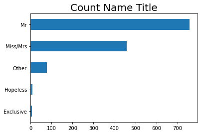

```python
df_name_title['Name'].value_counts().sort_values().plot(kind='barh')
plt.gca().set_title("Count Name Title", fontsize=20)
plt.show()
```

### Convert Sex to Numerical Value

```python
df_encode_sex = df_name_title.copy()
df_encode_sex['Sex'] = df_encode_sex['Sex'].map({'male':1, 'female':0})
df_encode_sex.head()
```

| PassengerId | Pclass | Name | Sex | Age | SibSp | Parch | Ticket | Fare | Cabin | Embarked |
| --- | --- | --- | --- | --- | --- | --- | --- | --- | --- | --- |
| 1 | 3 | Mr | 1 | 22.0 | 1 | 0 | A/5 21171 | 7.2500 | NaN | S |
| 2 | 1 | Miss/Mrs | 0 | 38.0 | 1 | 0 | PC 17599 | 71.2833 | C85 | C |
| 3 | 3 | Miss/Mrs | 0 | 26.0 | 0 | 0 | STON/O2. 3101282 | 7.9250 | NaN | S |
| 4 | 1 | Miss/Mrs | 0 | 35.0 | 1 | 0 | 113803 | 53.1000 | C123 | S |
| 5 | 3 | Mr | 1 | 35.0 | 0 | 0 | 373450 | 8.0500 | NaN | S |

#### "SibSp and Parch" Features

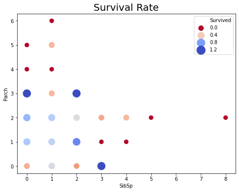

```python
family_probs = call_train_data(df_encode_sex).groupby(['SibSp','Parch']).Survived.mean().reset_index()

plt.figure(figsize=(8,6))
sns.scatterplot(x = "SibSp", y="Parch", size='Survived', hue='Survived',
                palette='coolwarm_r', sizes=(100,300), legend='brief', data=family_probs)
plt.title("Survival Rate", fontsize=20)
plt.show()
```

```
0     790
1     235
2     159
3      43
4      22
5      25
6      16
7       8
10     11
Name: FamilySize, dtype: int64
```

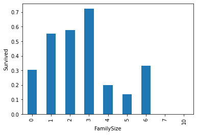

```python
df_family = df_encode_sex.copy()
df_family['FamilySize'] = df_family['SibSp'] + df_family['Parch']
print(df_family['FamilySize'].value_counts().sort_index())

call_train_data(df_family).groupby(['FamilySize'])['Survived'].mean().plot(kind='bar')
plt.ylabel("Survived")
plt.show()
```

```python
family_probs_dict = call_train_data(df_family).groupby(['SibSp','Parch']).Survived.mean().to_dict()
df_family['FamilyProbs'] = df_family.set_index(['SibSp','Parch']).index.map(family_probs_dict).to_numpy()
df_family['FamilyProbs'] = df_family['FamilyProbs'].fillna(0.5)

df_family.loc[df_family['FamilySize']<1, 'FamilySz'] = 'alone'
df_family.loc[(df_family['FamilySize']>=1) & (df_family['FamilySize']<4), 'FamilySz'] = 'small'
df_family.loc[(df_family['FamilySize']>=4) & (df_family['FamilySize']<7), 'FamilySz'] = 'medium'
df_family.loc[df_family['FamilySize']>=7, 'FamilySz'] = 'high'

df_family.drop(columns=['FamilySize'], inplace=True)
df_family.rename(columns={'FamilySz':'FamilySize'}, inplace=True)
df_family.head()
```

| PassengerId | Pclass | Name | Sex | Age | SibSp | Parch | Ticket | Fare | Cabin | Embarked | FamilyProbs | FamilySize |
| --- | --- | --- | --- | --- | --- | --- | --- | --- | --- | --- | --- | --- |
| 1 | 3 | Mr | 1 | 22.0 | 1 | 0 | A/5 21171 | 7.2500 | NaN | S | 0.520325 | small |
| 2 | 1 | Miss/Mrs | 0 | 38.0 | 1 | 0 | PC 17599 | 71.2833 | C85 | C | 0.520325 | small |
| 3 | 3 | Miss/Mrs | 0 | 26.0 | 0 | 0 | STON/O2. 3101282 | 7.9250 | NaN | S | 0.303538 | alone |
| 4 | 1 | Miss/Mrs | 0 | 35.0 | 1 | 0 | 113803 | 53.1000 | C123 | S | 0.520325 | small |
| 5 | 3 | Mr | 1 | 35.0 | 0 | 0 | 373450 | 8.0500 | NaN | S | 0.303538 | alone |

### Preprocessing "Ticket" Feature

```python
df_family['Ticket'].apply(lambda x: str(x[0])).value_counts(dropna=False)
```

```
3    429
2    278
1    210
P     98
S     98
C     77
A     42
W     19
F     13
7     13
4     11
6      9
L      5
5      3
9      2
8      2
Name: Ticket, dtype: int64
```

Ticket feature has high variation of unique value, so this will not give so much information. Hence, define new feature about Ticket relation and Fare more make sense.

```python
# Extract Ticket First Letter
df_encode_ticket = df_family.copy()
df_encode_ticket['Ticket'] = df_encode_ticket['Ticket'].apply(lambda x: str(x[0]))

# Average Ticket Fare by Other Features
filter_cols = ['Ticket','Embarked','Pclass','FamilySize']
ticket_class = df_encode_ticket.dropna().groupby(filter_cols).Fare.mean().reset_index()
ticket_class.rename(columns={'Fare':'TicketClass'}, inplace=True)

# Merge dataframe with aggregated ticket_class
df_encode_ticket = df_encode_ticket.merge(ticket_class, how='left',
                                          left_on=filter_cols, right_on=filter_cols)
df_encode_ticket.index = df_family.index
df_encode_ticket['TicketClass'].fillna(df_encode_ticket['TicketClass'].median(), inplace=True)

df_encode_ticket.groupby("Pclass")['TicketClass'].agg([min,'median','mean',max])
```

| Pclass | min | median | mean | max |
| --- | --- | --- | --- | --- |
| 1 | 13.0000 | 77.069433 | 88.302508 | 263.000000 |
| 2 | 10.5000 | 13.000000 | 18.032069 | 33.428571 |
| 3 | 7.2292 | 11.468750 | 10.676868 | 16.700000 |

```python
t = call_train_data(df_encode_ticket)
t[t['Fare'] > 263].Survived.mean()
```

```
1.0
```

```python
df_encode_ticket.loc[(df_encode_ticket['TicketClass']>=0) & (df_encode_ticket['TicketClass']<11), 'TicketClass'] = 1
df_encode_ticket.loc[(df_encode_ticket['TicketClass']>=11) & (df_encode_ticket['TicketClass']<18.5), 'TicketClass'] = 2
df_encode_ticket.loc[(df_encode_ticket['TicketClass']>=18.5) & (df_encode_ticket['TicketClass']<35), 'TicketClass'] = 3
df_encode_ticket.loc[(df_encode_ticket['TicketClass']>=35) & (df_encode_ticket['TicketClass']<80), 'TicketClass'] = 4
df_encode_ticket.loc[(df_encode_ticket['TicketClass']>=80) & (df_encode_ticket['TicketClass']<90), 'TicketClass'] = 5
df_encode_ticket.loc[df_encode_ticket['TicketClass']>=90, 'TicketClass'] = 6

df_encode_ticket['TicketClass'] = df_encode_ticket['TicketClass'].astype(int)
df_encode_ticket['Ticket'] = df_encode_ticket['Ticket'].apply(lambda x: x.isdigit()).astype(int)
df_encode_ticket['TicketClass'].value_counts(dropna=False)
```

```
2    584
1    332
4    155
6    147
3     79
5     12
Name: TicketClass, dtype: int64
```

### Preprocessing "Cabin" & "Embarked" Features

### Titanic Ship Cabin Map

[figure not shown]

*src : https://en.wikipedia.org/wiki/Sinking_of_the_Titanic#/media/File:Titanic_side_plan_annotated_English.png*

```
NaN    1014
C        94
B        65
D        46
E        41
A        22
F        21
G         5
T         1
Name: Cabin, dtype: int64
```

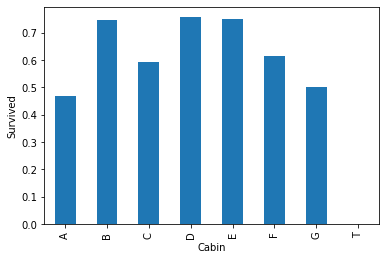

```python
df_encode_cabin = df_encode_ticket.copy()
df_encode_cabin['Cabin'] = df_encode_cabin['Cabin'].str[0]
print(df_encode_cabin.Cabin.value_counts(dropna=False))

call_train_data(df_encode_cabin).groupby(['Cabin'])['Survived'].mean().plot(kind='bar')
plt.ylabel('Survived')
plt.show()
```

Identify new feature whether Cabin is available and defined as "HasCabin", categorized cabin based on closest survival rate.

```python
df_encode_cabin['HasCabin'] = df_encode_cabin['Cabin'].notna().astype("int")
df_encode_cabin.loc[df_encode_cabin['Cabin'].isin(['B','D','E']), 'Cabin'] = 'BDE'
df_encode_cabin.loc[df_encode_cabin['Cabin'].isin(['C','F']), 'Cabin'] = 'CF'
df_encode_cabin.loc[df_encode_cabin['Cabin'].isin(['A','G']), 'Cabin'] = 'AG'
df_encode_cabin.loc[df_encode_cabin['Cabin']=='T', 'Cabin'] = 'UN'
df_encode_cabin.loc[df_encode_cabin['Cabin'].isnull(), 'Cabin'] = 'UN'

df_encode_cabin.groupby("Cabin").mean()
```

| Cabin | Pclass | Sex | Age | SibSp | Parch | Ticket | Fare | FamilyProbs | TicketClass | HasCabin |
| --- | --- | --- | --- | --- | --- | --- | --- | --- | --- | --- |
| AG | 1.370370 | 0.666667 | 37.458333 | 0.259259 | 0.370370 | 0.629630 | 36.237033 | 0.418127 | 4.481481 | 1.000000 |
| BDE | 1.105263 | 0.486842 | 37.860140 | 0.407895 | 0.467105 | 0.684211 | 83.094656 | 0.461996 | 4.611842 | 1.000000 |
| CF | 1.252174 | 0.530435 | 35.431923 | 0.634783 | 0.434783 | 0.773913 | 91.519712 | 0.439647 | 4.452174 | 1.000000 |
| UN | 2.615764 | 0.679803 | 27.429355 | 0.503448 | 0.367488 | 0.735961 | 19.148849 | 0.368267 | 1.935961 | 0.000985 |

### Impute "Embarked"

```python
raw_train_data.set_index("PassengerId")[['Name']].join(df_encode_cabin[df_encode_cabin['Embarked'].isnull()],
                                                       rsuffix='_', how='inner')
```

| PassengerId | Name | Pclass | Name_ | Sex | Age | SibSp | Parch | Ticket | Fare | Cabin | Embarked | FamilyProbs | FamilySize | TicketClass | HasCabin |
| --- | --- | --- | --- | --- | --- | --- | --- | --- | --- | --- | --- | --- | --- | --- | --- |
| 62 | Icard, Miss. Amelie | 1 | Miss/Mrs | 0 | 38.0 | 0 | 0 | 1 | 80.0 | BDE | NaN | 0.303538 | alone | 2 | 1 |
| 830 | Stone, Mrs. George Nelson (Martha Evelyn) | 1 | Miss/Mrs | 0 | 62.0 | 0 | 0 | 1 | 80.0 | BDE | NaN | 0.303538 | alone | 2 | 1 |

According to https://www.encyclopedia-titanica.org/titanic-survivor/, both passenger with unknown embarked has Embarked from Southampton(S)

[figure not shown]

```python
df_encode_embarked = df_encode_cabin.copy()
df_encode_embarked['Embarked'] = df_encode_embarked['Embarked'].fillna('S')
df_encode_embarked['Embarked'].value_counts()
```

```
S    916
C    270
Q    123
Name: Embarked, dtype: int64
```

Check other feature which contain missing value

```python
count_missing_value(df_encode_embarked)
```

```
Age     263
Fare      1
dtype: int64
```

### Preprocessing "Age" Features

Display passenger with missing Age

```python
check_age = df_encode_embarked[df_encode_embarked.Age.isnull()].head(7)
check_index = check_age.index
check_age
```

| PassengerId | Pclass | Name | Sex | Age | SibSp | Parch | Ticket | Fare | Cabin | Embarked | FamilyProbs | FamilySize | TicketClass | HasCabin |
| --- | --- | --- | --- | --- | --- | --- | --- | --- | --- | --- | --- | --- | --- | --- |
| 6 | 3 | Mr | 1 | NaN | 0 | 0 | 1 | 8.4583 | UN | Q | 0.303538 | alone | 2 | 0 |
| 18 | 2 | Mr | 1 | NaN | 0 | 0 | 1 | 13.0000 | UN | S | 0.303538 | alone | 2 | 0 |
| 20 | 3 | Miss/Mrs | 0 | NaN | 0 | 0 | 1 | 7.2250 | UN | C | 0.303538 | alone | 1 | 0 |
| 27 | 3 | Mr | 1 | NaN | 0 | 0 | 1 | 7.2250 | UN | C | 0.303538 | alone | 1 | 0 |
| 29 | 3 | Miss/Mrs | 0 | NaN | 0 | 0 | 1 | 7.8792 | UN | Q | 0.303538 | alone | 2 | 0 |
| 30 | 3 | Mr | 1 | NaN | 0 | 0 | 1 | 7.8958 | UN | S | 0.303538 | alone | 1 | 0 |
| 32 | 1 | Miss/Mrs | 0 | NaN | 1 | 0 | 0 | 146.5208 | BDE | C | 0.520325 | small | 6 | 1 |

Grouping dataframe to find out appropriate age based on other feature, and will be used for impute missing Age

```python
df_encode_embarked.corr()['Age'].sort_values().round(2).to_frame()
```

|  | Age |
| --- | --- |
| Pclass | -0.41 |
| SibSp | -0.24 |
| Parch | -0.15 |
| FamilyProbs | -0.06 |
| Ticket | -0.03 |
| Sex | 0.06 |
| Fare | 0.18 |
| HasCabin | 0.29 |
| TicketClass | 0.33 |
| Age | 1.00 |

```python
df_encode_embarked.groupby(['Pclass','Sex','TicketClass'])['Age'].transform(lambda x: x.fillna(x.mean()))[check_index]
```

```
PassengerId
6     23.784233
18    32.163265
20    23.750000
27    27.870968
29    21.699741
30    27.870968
32    37.842105
Name: Age, dtype: float64
```

```python
df_impute_age = df_encode_embarked.copy()
df_impute_age['Age'] = df_encode_embarked.groupby(['Pclass','Sex','TicketClass'])['Age'].transform(lambda x: x.fillna(x.mean()))
df_impute_age['Age'].fillna(df_impute_age['Age'].median(), inplace=True)

# Check if imputed Age value make sense
df_impute_age.loc[check_index]
```

| PassengerId | Pclass | Name | Sex | Age | SibSp | Parch | Ticket | Fare | Cabin | Embarked | FamilyProbs | FamilySize | TicketClass | HasCabin |
| --- | --- | --- | --- | --- | --- | --- | --- | --- | --- | --- | --- | --- | --- | --- |
| 6 | 3 | Mr | 1 | 23.784233 | 0 | 0 | 1 | 8.4583 | UN | Q | 0.303538 | alone | 2 | 0 |
| 18 | 2 | Mr | 1 | 32.163265 | 0 | 0 | 1 | 13.0000 | UN | S | 0.303538 | alone | 2 | 0 |
| 20 | 3 | Miss/Mrs | 0 | 23.750000 | 0 | 0 | 1 | 7.2250 | UN | C | 0.303538 | alone | 1 | 0 |
| 27 | 3 | Mr | 1 | 27.870968 | 0 | 0 | 1 | 7.2250 | UN | C | 0.303538 | alone | 1 | 0 |
| 29 | 3 | Miss/Mrs | 0 | 21.699741 | 0 | 0 | 1 | 7.8792 | UN | Q | 0.303538 | alone | 2 | 0 |
| 30 | 3 | Mr | 1 | 27.870968 | 0 | 0 | 1 | 7.8958 | UN | S | 0.303538 | alone | 1 | 0 |
| 32 | 1 | Miss/Mrs | 0 | 37.842105 | 1 | 0 | 0 | 146.5208 | BDE | C | 0.520325 | small | 6 | 1 |

### "Fare" Feature

```python
df_fare = df_impute_age.copy()
df_fare[df_fare['Fare'].isnull()]
```

| PassengerId | Pclass | Name | Sex | Age | SibSp | Parch | Ticket | Fare | Cabin | Embarked | FamilyProbs | FamilySize | TicketClass | HasCabin |
| --- | --- | --- | --- | --- | --- | --- | --- | --- | --- | --- | --- | --- | --- | --- |
| 1044 | 3 | Mr | 1 | 60.5 | 0 | 0 | 1 | NaN | UN | S | 0.303538 | alone | 1 | 0 |

```python
df_fare.corr()['Fare'].round(3).sort_values().to_frame()
```

|  | Fare |
| --- | --- |
| Pclass | -0.559 |
| Sex | -0.186 |
| Ticket | -0.175 |
| FamilyProbs | 0.157 |
| SibSp | 0.160 |
| Age | 0.196 |
| Parch | 0.222 |
| HasCabin | 0.507 |
| TicketClass | 0.668 |
| Fare | 1.000 |

```python
# This passenger departs Embarked 'S', with Pclass 3 and TicketClass 1
df_fare.groupby(['Embarked','Pclass','TicketClass'])['Fare'].agg([min,'median','mean',max]).loc[('S',3,1)]
```

```
min        6.237500
median     7.895800
mean       8.234088
max       39.687500
Name: (S, 3, 1), dtype: float64
```

```python
df_fare['Fare'].fillna(8, inplace=True)
```

```python
df_final = df_fare.copy()
df_final.describe(include='all').T
```

|  | count | unique | top | freq | mean | std | min | 25% | 50% | 75% | max |
| --- | --- | --- | --- | --- | --- | --- | --- | --- | --- | --- | --- |
| Pclass | 1309 | NaN | NaN | NaN | 2.29488 | 0.837836 | 1 | 2 | 3 | 3 | 3 |
| Name | 1309 | 5 | Mr | 757 | NaN | NaN | NaN | NaN | NaN | NaN | NaN |
| Sex | 1309 | NaN | NaN | NaN | 0.644003 | 0.478997 | 0 | 0 | 1 | 1 | 1 |
| Age | 1309 | NaN | NaN | NaN | 29.3042 | 13.1927 | 0.17 | 21.6997 | 27.871 | 36 | 80 |
| SibSp | 1309 | NaN | NaN | NaN | 0.498854 | 1.04166 | 0 | 0 | 0 | 1 | 8 |
| Parch | 1309 | NaN | NaN | NaN | 0.385027 | 0.86556 | 0 | 0 | 0 | 0 | 9 |
| Ticket | 1309 | NaN | NaN | NaN | 0.731092 | 0.443561 | 0 | 0 | 1 | 1 | 1 |
| Fare | 1309 | NaN | NaN | NaN | 33.2762 | 51.7436 | 0 | 7.8958 | 14.4542 | 31.275 | 512.329 |
| Cabin | 1309 | 4 | UN | 1015 | NaN | NaN | NaN | NaN | NaN | NaN | NaN |
| Embarked | 1309 | 3 | S | 916 | NaN | NaN | NaN | NaN | NaN | NaN | NaN |
| FamilyProbs | 1309 | NaN | NaN | NaN | 0.38645 | 0.162901 | 0 | 0.303538 | 0.303538 | 0.520325 | 1 |
| FamilySize | 1309 | 4 | alone | 790 | NaN | NaN | NaN | NaN | NaN | NaN | NaN |
| TicketClass | 1309 | NaN | NaN | NaN | 2.52024 | 1.54858 | 1 | 1 | 2 | 3 | 6 |
| HasCabin | 1309 | NaN | NaN | NaN | 0.225363 | 0.417981 | 0 | 0 | 0 | 0 | 1 |

Casting features data type

```python
age_group = 20
fare_group = 26

df_final['Age'] = pd.qcut(df_final['Age'], age_group,
                         labels=list(range(age_group))).astype(int)
df_final['Fare'] = pd.qcut(df_final['Fare'], fare_group,
                          labels=list(range(fare_group))).astype(int)
df_final.sample(8)
```

| PassengerId | Pclass | Name | Sex | Age | SibSp | Parch | Ticket | Fare | Cabin | Embarked | FamilyProbs | FamilySize | TicketClass | HasCabin |
| --- | --- | --- | --- | --- | --- | --- | --- | --- | --- | --- | --- | --- | --- | --- |
| 1275 | 3 | Miss/Mrs | 0 | 2 | 1 | 0 | 1 | 14 | UN | S | 0.520325 | small | 2 | 0 |
| 535 | 3 | Miss/Mrs | 0 | 11 | 0 | 0 | 1 | 8 | UN | S | 0.303538 | alone | 1 | 0 |
| 357 | 1 | Miss/Mrs | 0 | 5 | 0 | 1 | 1 | 21 | BDE | S | 0.657895 | small | 4 | 1 |
| 193 | 3 | Miss/Mrs | 0 | 2 | 1 | 0 | 1 | 5 | UN | S | 0.520325 | small | 2 | 0 |
| 4 | 1 | Miss/Mrs | 0 | 14 | 1 | 0 | 1 | 21 | CF | S | 0.520325 | small | 4 | 1 |
| 943 | 2 | Mr | 1 | 9 | 0 | 0 | 0 | 13 | UN | C | 0.303538 | alone | 2 | 0 |
| 603 | 1 | Mr | 1 | 16 | 0 | 0 | 1 | 20 | UN | S | 0.303538 | alone | 4 | 0 |
| 37 | 3 | Mr | 1 | 9 | 0 | 0 | 1 | 1 | UN | C | 0.303538 | alone | 1 | 0 |

Encode categorical(numerical) columns to one hot shape

```python
def one_hot_encoding(data, columns):
    nominal_df = []

    for nc in columns:
        onehot_df = pd.get_dummies(data[nc], prefix=nc)
        onehot_df.drop(onehot_df.columns[-1], axis=1, inplace=True)

        # Avoid multicolinearity
        data.drop(columns=[nc], inplace=True)
        nominal_df.append(onehot_df)

    onehot_combined = pd.concat(nominal_df, axis=1)

    data = data.join(onehot_combined)
    return data
```

```python
categorical_columns = ['Name','Embarked','Cabin','FamilySize']
df_final = one_hot_encoding(df_final, categorical_columns)

df_final.describe().T
```

|  | count | mean | std | min | 25% | 50% | 75% | max |
| --- | --- | --- | --- | --- | --- | --- | --- | --- |
| Pclass | 1309.0 | 2.294882 | 0.837836 | 1.0 | 2.000000 | 3.000000 | 3.000000 | 3.0 |
| Sex | 1309.0 | 0.644003 | 0.478997 | 0.0 | 0.000000 | 1.000000 | 1.000000 | 1.0 |
| Age | 1309.0 | 9.191749 | 5.810651 | 0.0 | 4.000000 | 9.000000 | 14.000000 | 19.0 |
| SibSp | 1309.0 | 0.498854 | 1.041658 | 0.0 | 0.000000 | 0.000000 | 1.000000 | 8.0 |
| Parch | 1309.0 | 0.385027 | 0.865560 | 0.0 | 0.000000 | 0.000000 | 0.000000 | 9.0 |
| Ticket | 1309.0 | 0.731092 | 0.443561 | 0.0 | 0.000000 | 1.000000 | 1.000000 | 1.0 |
| Fare | 1309.0 | 12.348358 | 7.551310 | 0.0 | 5.000000 | 12.000000 | 19.000000 | 25.0 |
| FamilyProbs | 1309.0 | 0.386450 | 0.162901 | 0.0 | 0.303538 | 0.303538 | 0.520325 | 1.0 |
| TicketClass | 1309.0 | 2.520244 | 1.548580 | 1.0 | 1.000000 | 2.000000 | 3.000000 | 6.0 |
| HasCabin | 1309.0 | 0.225363 | 0.417981 | 0.0 | 0.000000 | 0.000000 | 0.000000 | 1.0 |
| Name_Exclusive | 1309.0 | 0.006112 | 0.077967 | 0.0 | 0.000000 | 0.000000 | 0.000000 | 1.0 |
| Name_Hopeless | 1309.0 | 0.007639 | 0.087103 | 0.0 | 0.000000 | 0.000000 | 0.000000 | 1.0 |
| Name_Miss/Mrs | 1309.0 | 0.349121 | 0.476875 | 0.0 | 0.000000 | 0.000000 | 1.000000 | 1.0 |
| Name_Mr | 1309.0 | 0.578304 | 0.494019 | 0.0 | 0.000000 | 1.000000 | 1.000000 | 1.0 |
| Embarked_C | 1309.0 | 0.206264 | 0.404777 | 0.0 | 0.000000 | 0.000000 | 0.000000 | 1.0 |
| Embarked_Q | 1309.0 | 0.093965 | 0.291891 | 0.0 | 0.000000 | 0.000000 | 0.000000 | 1.0 |
| Cabin_AG | 1309.0 | 0.020626 | 0.142184 | 0.0 | 0.000000 | 0.000000 | 0.000000 | 1.0 |
| Cabin_BDE | 1309.0 | 0.116119 | 0.320490 | 0.0 | 0.000000 | 0.000000 | 0.000000 | 1.0 |
| Cabin_CF | 1309.0 | 0.087853 | 0.283190 | 0.0 | 0.000000 | 0.000000 | 0.000000 | 1.0 |
| FamilySize_alone | 1309.0 | 0.603514 | 0.489354 | 0.0 | 0.000000 | 1.000000 | 1.000000 | 1.0 |
| FamilySize_high | 1309.0 | 0.014515 | 0.119646 | 0.0 | 0.000000 | 0.000000 | 0.000000 | 1.0 |
| FamilySize_medium | 1309.0 | 0.048128 | 0.214119 | 0.0 | 0.000000 | 0.000000 | 0.000000 | 1.0 |

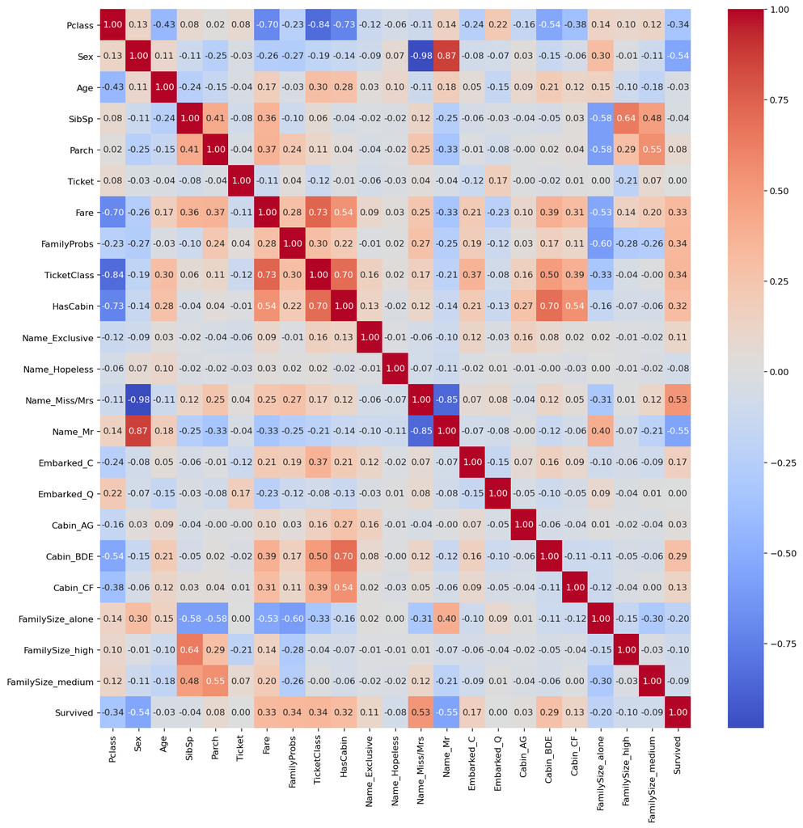

```python
fdata = call_train_data(df_final)
fdata_corr = fdata.corr()

plt.figure(figsize=(15,15), dpi=120)
sns.heatmap(fdata_corr, fmt=".2f", annot=True, cmap='coolwarm')
plt.show()
```

Select features which have correlation value >= 0.01 or <= -0.01 with 'Survived' column

```python
feature_filter = (fdata_corr['Survived'] <= -0.01) | (fdata_corr['Survived'] >= 0.01)
selected_features = fdata_corr.index[feature_filter].drop('Survived')
print("Selected Features :")
print(selected_features)

df_final = df_final[selected_features]
df_final.sample(5)
```

```
Selected Features :
Index(['Pclass', 'Sex', 'Age', 'SibSp', 'Parch', 'Fare', 'FamilyProbs',
       'TicketClass', 'HasCabin', 'Name_Exclusive', 'Name_Hopeless',
       'Name_Miss/Mrs', 'Name_Mr', 'Embarked_C', 'Cabin_AG', 'Cabin_BDE',
       'Cabin_CF', 'FamilySize_alone', 'FamilySize_high', 'FamilySize_medium'],
      dtype='object')
```

| PassengerId | Pclass | Sex | Age | SibSp | Parch | Fare | FamilyProbs | TicketClass | HasCabin | Name_Exclusive | Name_Hopeless | Name_Miss/Mrs | Name_Mr | Embarked_C | Cabin_AG | Cabin_BDE | Cabin_CF | FamilySize_alone | FamilySize_high | FamilySize_medium |
| --- | --- | --- | --- | --- | --- | --- | --- | --- | --- | --- | --- | --- | --- | --- | --- | --- | --- | --- | --- | --- |
| 829 | 3 | 1 | 6 | 0 | 0 | 3 | 0.303538 | 2 | 0 | 0 | 0 | 0 | 1 | 0 | 0 | 0 | 0 | 1 | 0 | 0 |
| 205 | 3 | 1 | 2 | 0 | 0 | 7 | 0.303538 | 2 | 0 | 0 | 0 | 0 | 1 | 0 | 0 | 0 | 0 | 1 | 0 | 0 |
| 980 | 3 | 0 | 4 | 0 | 0 | 3 | 0.303538 | 2 | 0 | 1 | 0 | 0 | 0 | 0 | 0 | 0 | 0 | 1 | 0 | 0 |
| 1257 | 3 | 0 | 4 | 1 | 9 | 22 | 0.500000 | 2 | 0 | 0 | 0 | 1 | 0 | 0 | 0 | 0 | 0 | 0 | 1 | 0 |
| 830 | 1 | 0 | 19 | 0 | 0 | 23 | 0.303538 | 2 | 1 | 0 | 0 | 1 | 0 | 0 | 0 | 1 | 0 | 1 | 0 | 0 |

### Modelling

Define train and test data

```python
train_data = df_final.loc[raw_train_data['PassengerId'].values].reset_index(drop=True)
train_data = train_data.join(raw_train_data['Survived'])

test_data = df_final.loc[~df_final.index.isin(raw_train_data['PassengerId'])]
train_data.head()
```

|  | Pclass | Sex | Age | SibSp | Parch | Fare | FamilyProbs | TicketClass | HasCabin | Name_Exclusive | ... | Name_Miss/Mrs | Name_Mr | Embarked_C | Cabin_AG | Cabin_BDE | Cabin_CF | FamilySize_alone | FamilySize_high | FamilySize_medium | Survived |
| --- | --- | --- | --- | --- | --- | --- | --- | --- | --- | --- | --- | --- | --- | --- | --- | --- | --- | --- | --- | --- | --- |
| 0 | 3 | 1 | 5 | 1 | 0 | 1 | 0.520325 | 2 | 0 | 0 | ... | 0 | 1 | 0 | 0 | 0 | 0 | 0 | 0 | 0 | 0 |
| 1 | 1 | 0 | 15 | 1 | 0 | 22 | 0.520325 | 6 | 1 | 0 | ... | 1 | 0 | 1 | 0 | 0 | 1 | 0 | 0 | 0 | 1 |
| 2 | 3 | 0 | 8 | 0 | 0 | 6 | 0.303538 | 1 | 0 | 0 | ... | 1 | 0 | 0 | 0 | 0 | 0 | 1 | 0 | 0 | 1 |
| 3 | 1 | 0 | 14 | 1 | 0 | 21 | 0.520325 | 4 | 1 | 0 | ... | 1 | 0 | 0 | 0 | 0 | 1 | 0 | 0 | 0 | 1 |
| 4 | 3 | 1 | 14 | 0 | 0 | 7 | 0.303538 | 1 | 0 | 0 | ... | 0 | 1 | 0 | 0 | 0 | 0 | 1 | 0 | 0 | 0 |

5 rows × 21 columns

```python
train_data.Survived.value_counts()
```

```
0    549
1    342
Name: Survived, dtype: int64
```

Training data seem imbalanced, that can hurt model performance. So there need to be balanced in 1:1 ratio

```python
def balance_class(data):
    df = data.copy()
    survived_idx = df[df.Survived==1].index

    df = pd.concat([df.loc[survived_idx], \
                    df.loc[~df.index.isin(survived_idx)].sample(len(survived_idx))])

    df = df.sample(frac=1).reset_index(drop=True)
    return df
```

```python
def select_best_model(X, y, test_size=0.2, standarize=False, balance=False):
    """
    Find classification model based on some evaluation metrics

    Cache contain used training and evaluation data

    model_report describe how is performance for each model

    Return - cache, best_model, model_report
    """
    if balance==True:
        df = pd.concat([X,y], axis=1)
        df = balance_class(df)
        y = df['Survived']
        X = df.drop(columns=['Survived'], axis=1)

    X_train, X_val, y_train, y_val = train_test_split(X, y, test_size=test_size, random_state=7)

    best_model = []
    best_score = 0
    models = [LogisticRegression(max_iter=1000),
              DecisionTreeClassifier(),
              RandomForestClassifier(),
              GradientBoostingClassifier(),
              XGBClassifier(),
              AdaBoostClassifier(),
              BaggingClassifier(),
              ExtraTreesClassifier(),
              MLPClassifier(max_iter=1000, hidden_layer_sizes=(64,32,16,8,4,)),
              KNeighborsClassifier(n_neighbors=5)]

    f1_scores = []
    roc_auc_scores = []
    train_scores = []
    accuracy_scores = []
    model_names = []

    for model in models:
        model.fit(X_train, y_train)

        y_predicted = model.predict(X_val)
        score = f1_score(y_predicted, y_val)

        if(score>best_score):
            best_model = model
            best_score = score

        f1_scores.append(score)
        roc_auc_scores.append(roc_auc_score(y_predicted, y_val))
        accuracy_scores.append(accuracy_score(y_predicted, y_val))
        train_scores.append(model.score(X_train, y_train))
        model_names.append(model.__class__.__name__)

    model_report = pd.DataFrame({'F1 Score' : f1_scores,
                                 'ROC-AUC Score' : roc_auc_scores,
                                 'Validation Accuracy Score': accuracy_scores,
                                 'Training Accuracy Score': train_scores,
                                 'Model' : model_names})

    model_report.set_index('Model', inplace=True)
    model_report.sort_values(by=['F1 Score','Validation Accuracy Score'], ascending=False, inplace=True)
    cache = [X_train, X_val, y_train, y_val]

    return cache, best_model, model_report
```

### Get Model Summary, and Best Model

```python
X = train_data[test_data.columns]
y = train_data['Survived']
cache, best_model, model_report = select_best_model(X, y, test_size=0.3, standarize=False, balance=True)
```

### Model Comparation

```python
model_report
```

| Model | F1 Score | ROC-AUC Score | Validation Accuracy Score | Training Accuracy Score |
| --- | --- | --- | --- | --- |
| GradientBoostingClassifier | 0.805430 | 0.789588 | 0.791262 | 0.914226 |
| LogisticRegression | 0.796380 | 0.779856 | 0.781553 | 0.853556 |
| XGBClassifier | 0.792627 | 0.781109 | 0.781553 | 0.974895 |
| MLPClassifier | 0.788991 | 0.775860 | 0.776699 | 0.916318 |
| ExtraTreesClassifier | 0.784141 | 0.759916 | 0.762136 | 0.987448 |
| RandomForestClassifier | 0.780269 | 0.760038 | 0.762136 | 0.987448 |
| AdaBoostClassifier | 0.778761 | 0.754972 | 0.757282 | 0.857741 |
| BaggingClassifier | 0.778281 | 0.760393 | 0.762136 | 0.976987 |
| DecisionTreeClassifier | 0.760181 | 0.740930 | 0.742718 | 0.987448 |
| KNeighborsClassifier | 0.757991 | 0.741509 | 0.742718 | 0.855649 |

```python
# Retrive training and validation data
X_train, X_val, y_train, y_val = cache
```

```python
model = XGBClassifier()

param_dist = {'n_estimators': list(range(10,150)),
             'max_depth': list(range(3,30)),
             'min_samples_split': list(range(2, 11)),
             'criterion' : ['gini','entropy'],
             'bootstrap' : [True, False]}

n_iter = 50
random_search = RandomizedSearchCV(model,
                                   param_distributions=param_dist,
                                   scoring='accuracy',
                                   n_iter=n_iter,
                                   cv = 5)
random_search.fit(X, y)
```

[output not shown]

[output cut: 1951 more lines]

[output not shown]

```
RandomizedSearchCV(cv=5,
                   estimator=XGBClassifier(base_score=None, booster=None,
                                           colsample_bylevel=None,
                                           colsample_bynode=None,
                                           colsample_bytree=None, gamma=None,
                                           gpu_id=None, importance_type='gain',
                                           interaction_constraints=None,
                                           learning_rate=None,
                                           max_delta_step=None, max_depth=None,
                                           min_child_weight=None, missing=nan,
                                           monotone_constraints=None,
                                           n_estimators=100,...
                                           verbosity=None),
                   n_iter=50,
                   param_distributions={'bootstrap': [True, False],
                                        'criterion': ['gini', 'entropy'],
                                        'max_depth': [3, 4, 5, 6, 7, 8, 9, 10,
                                                      11, 12, 13, 14, 15, 16,
                                                      17, 18, 19, 20, 21, 22,
                                                      23, 24, 25, 26, 27, 28,
                                                      29],
                                        'min_samples_split': [2, 3, 4, 5, 6, 7,
                                                              8, 9, 10],
                                        'n_estimators': [10, 11, 12, 13, 14, 15,
                                                         16, 17, 18, 19, 20, 21,
                                                         22, 23, 24, 25, 26, 27,
                                                         28, 29, 30, 31, 32, 33,
                                                         34, 35, 36, 37, 38, 39, ...]},
                   scoring='accuracy')
```

```python
best_hyp = pd.DataFrame(random_search.cv_results_).sort_values('rank_test_score')

for i, row in best_hyp.head(3).iterrows():
     print('Model rank: {}'.format(row.rank_test_score))
     print('Mean validation score: {:.3f}, std: {:.3f}'.format(row.mean_test_score, row.std_test_score))
     print('Hyperparameters: {}\n'.format(row.params))
```

```
Model rank: 1
Mean validation score: 0.844, std: 0.016
Hyperparameters: {'n_estimators': 65, 'min_samples_split': 3, 'max_depth': 3, 'criterion': 'entropy', 'bootstrap': True}

Model rank: 2
Mean validation score: 0.842, std: 0.021
Hyperparameters: {'n_estimators': 71, 'min_samples_split': 10, 'max_depth': 3, 'criterion': 'entropy', 'bootstrap': False}

Model rank: 3
Mean validation score: 0.840, std: 0.026
Hyperparameters: {'n_estimators': 91, 'min_samples_split': 6, 'max_depth': 4, 'criterion': 'entropy', 'bootstrap': False}
```

```python
params =  {'n_estimators': 64, 'min_samples_split': 6, 'max_depth': 27, 'criterion': 'gini', 'bootstrap': True}
model = XGBClassifier(**params)
model.fit(X,y)
```

[output not shown]

```
XGBClassifier(base_score=0.5, booster='gbtree', bootstrap=True,
              colsample_bylevel=1, colsample_bynode=1, colsample_bytree=1,
              criterion='gini', gamma=0, gpu_id=-1, importance_type='gain',
              interaction_constraints='', learning_rate=0.300000012,
              max_delta_step=0, max_depth=27, min_child_weight=1,
              min_samples_split=6, missing=nan, monotone_constraints='()',
              n_estimators=64, n_jobs=0, num_parallel_tree=1, random_state=0,
              reg_alpha=0, reg_lambda=1, scale_pos_weight=1, subsample=1,
              tree_method='exact', validate_parameters=1, verbosity=None)
```

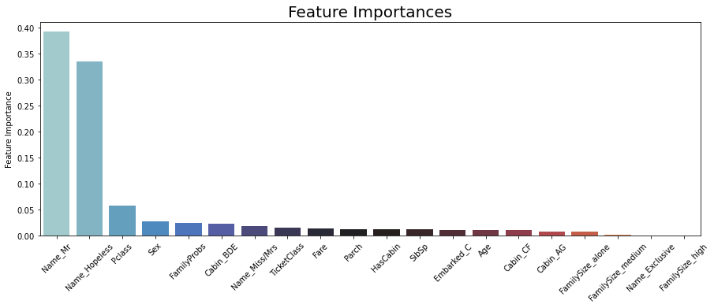

```python
feature_importance = pd.DataFrame(model.feature_importances_, columns=['Feature Importance'], index=X.columns).sort_values(by=['Feature Importance'], ascending=False)
plt.figure(figsize=(15,5))
sns.barplot(x=feature_importance.index, y=feature_importance['Feature Importance'], palette="icefire")
plt.xticks(rotation=45)
plt.title("Feature Importances", fontsize=20)
plt.show()
```

### Predict Test Data

```python
predicted = model.predict(test_data)
print(predicted.mean())
```

```
0.37320574162679426
```

```python
submission = pd.DataFrame({"PassengerId" : test_data.index,
                          "Survived":predicted})

print(submission.Survived.value_counts())
display(submission)
```

```
0    262
1    156
Name: Survived, dtype: int64
```

|  | PassengerId | Survived |
| --- | --- | --- |
| 0 | 892 | 0 |
| 1 | 893 | 0 |
| 2 | 894 | 0 |
| 3 | 895 | 0 |
| 4 | 896 | 0 |
| ... | ... | ... |
| 413 | 1305 | 0 |
| 414 | 1306 | 1 |
| 415 | 1307 | 0 |
| 416 | 1308 | 0 |
| 417 | 1309 | 1 |

418 rows × 2 columns

```python
submission.to_csv("submission.csv", index=False)
```